# Сплайновые поверхности

### Небольшое введение

В этом конспекте будут рассматриваться поверхности, и зайдет разговор о гладкости какой-либо поверхности. Вспомним, что это означает. Плоскость, заданная уравнением $\begin{bmatrix} x(u,v) \\ y(y,v) \\ z(u,v) \end{bmatrix} = \vec{R}(u,v)$ на связном множестве $G$ принадлежит множеству $C^k(G)$ (является $C^k$-гладкой), если функция $\vec{R}(u,v)$ является $C^k$-гладкой на множестве $G$, то есть имеет непрерывную производную до порядка $k$ включительно (если говорится о множестве $C^0(G)$, то непрерывной должна быть сама функция).

### Задача

Необходимо по заданному множеству вершин $\{\vec{P_{ij}}\}$ с учетом их нумерации построить гладкую поверхность, которая, плавно изменяясь, проходила бы вблизи этих вершин.

Важную роль в решении задачи играет многогранная поверхность, вершины которой совпадают с точками из заданного множеств. Назовем эту поверхность **опорной**. Она примерно показывает, как будет выглядеть искомая поверхность. Построенный на этих точках граф с ребрами, соответствующими граням в опорной поверхности, назовем **опорным графом**. В общем виде параметрическое уравнение искомой поверхности будет выглядеть так: $\vec{R}(u,v)=\sum\limits_{i=0}^n \sum\limits_{j=0}^m a_i(u) b_j(v) \vec{P_{ij}}$, где $a_i(u)$ и $b_j(v)$ $-$ некоторые функциональные коэффициенты.

Для решения поставленной задачи можно разбить множество $P$ на подмножества, для каждого подмножества построить по какой-нибудь простой схеме поверхность (назовем ее **элементарной**), и, соединив все полученные поверхности, найти искомую. Такие составные поверхности называются **сплайновыми**. При этом в каждом подмножестве в качестве коэффициентов $c_{ij}(u,v) = a_i(u) b_i(v)$ используются многочлены одной степени.

## Поверхности Безье

### Определение

По заданному множеству вершин $\{P_{ij}\}, 0 \le i \le n, 0 \le j \le m$ **поверхность Безье порядка $n \times m$** определяется следующим уравнением: $\vec{R}(u,v)=\sum\limits_{i=0}^n \sum\limits_{j=0}^m B_i^n(u)B_j^m(v)\vec{P_{ij}}, 0 \le u, v \le 1$ , где $B^n_i(u)=\binom{n}{i}u^i(1-u)^{n-i}$ $-$ многочлен Бернштейна. В случае, когда область изменения параметров $u$ и $v$ $-$ произвольный прямоугольник вида $R=\{(u,v)|a \le u \le b, c \le v \le d\}$, уравнение принимает следующий вид: $\vec{R}(u,v)=\sum\limits_{i=0}^n \sum\limits_{j=0}^m B_i^n(\dfrac{u - a}{b - a})B_j^m(\dfrac{v - c}{d - c})\vec{P_{ij}}$

### Некоторые свойства поверхностей Безье

#### Свойства полинома Бернштейна

- $\forall v, u: \sum\limits_{i=0}^n \sum\limits_{j=0}^m B_i^n(u)B_j^m(v)=\sum\limits_{i=0}^n B_i^n(u) \sum\limits_{j=0}^m B_j^m(v) = \sum\limits_{i=0}^n B_i^n(u) =1$, по свойствам, доказанным в конспекте кривой Безье
- $B_i^n(0)=\delta_0^i, B_i^n(1)=\delta_n^i$, где $\delta - $символ Кронекера.

#### Свойства поверхностей Безье

- Является гладкой поверхностью, так как задается полиномом от двух переменных.
- Граничные кривые поверхности есть суть кривые Безье. Взяв $v=const=0$ получаем $\vec{R}(u,0)=\sum\limits_{i=0}^n B_i^n(u) \sum\limits_{j=0}^m B_j^m(0)\vec{P_{ij}}$. Из свойства полинома Бернштейна получаем $\vec{R}(u,0)=\sum\limits_{i=0}^n B_i^n(u) \vec{P_{i0}}$, что является уравнением кривой Безье с опорным массивом $P_{00}, \dots,P_{n0}$.
- Угловые вершины опорного многогранника лежат на поверхности Безье. $R(0,0)=P_{00}, R(1,0)=P_{n0}, R(0,1)=P_{0m}, R(1,1)=P_{nm}$
- Производные в угловых вершинах (вычисление производных представлено ниже):

$\vec{R_u}(0,0)=n(\vec{P}_{10}-\vec{P}_{00})$,

$\vec{R_v}(0,0)=m(\vec{P}_{01}-\vec{P}_{00})$, то есть в угловых опорных точках поверхность касается звеньев опорного графа.

- Лежит в выпуклой оболочке, порожденной массивом $\vec{P}$.
- Если все вершины массива $\vec{P}$ лежат в одной плоскости, то и сама поверхность Безье лежит в этой плоскости
- Степень функциональных коэффициентов (многочленов Бернштейна) зависит напрямую от количества вершин в массиве.
- При изменении любой вершины возникает необходимость полного пересчета параметрических уравнений поверхности Безье

### Составные поверхности Безье

Рассмотрим составные бикубические поверхности Безье. **Составная бикубическая поверхность Безье** $-$ это непрерывная (но не обязательно гладкая) поверхность, являющаяся объединением элементарных бикубических поверхностей Безье.

Пусть

$\vec{R}=\vec{R^{(1)}}(u,v)$

$\vec{R}=\vec{R^{(2)}}(u,v)$ $-$ радиус-векторы двух элементарных поверхностей Безье, соответственно $S^{(1)}$ и $S^{(2)}$, порожденные массивами $\vec{P^{(1)}}$ и $\vec{P^{(2)}}$, притом $\vec{P^{(2)}_{nj}}=\vec{P^{(2)}_{0j}}$, то есть поверхности $S^{(1)}$ и $S^{(2)}$ имеют общую граничную кривую $\vec{R^{(1)}}(1,v)=\vec{R^{(2)}}(0,v)$. Так как граничные кривые обеих поверхностей имеют один и тот же опорный массив (массив граничных точек, что следует из свойств), они совпадают. Значит, составная поверхность непрерывна. Но интересует условие, при котором составная поверхность будет не только непрерывной, но и гладкой.

### Условие гладкости составных поверхностей Безье

**Лемма (производная уравнения поверхности Безье)**

> $\vec{R}(u,v) -$ поверхность Безье.

> Тогда $\vec{R_u}(u,v)=n\sum\limits_{i=0}^{n-1}\sum\limits_{j=0}^{m}(\vec{P}_{i+1,j}-\vec{P}_{i,j})B_i^{n-1}(u)B_j^m(v)$ , $\vec{R_v}(u,v)=m\sum\limits_{i=0}^{n}\sum\limits_{j=0}^{m - 1}(\vec{P}_{i,j+1}-\vec{P}_{i,j})B_i^{n}(u)B_j^{m-1}(v)$

**Теорема (условие гладкости составных поверхностей Безье)**

> $\vec{R^{(1)}}(u,v), \vec{R^{(2)}}(u,v) -$ две элементарные поверхности Безье, $ \forall 0 \le j \le m: \vec{P^{(2)}_{nj}}=\vec{P^{(2)}_{0j}}$.

> Тогда для того, чтобы составная поверхность была гладкой достаточно $\forall 0 \le j \le m : \vec{P^{(1)}}_{n,j}-\vec{P^{(1)}}_{n - 1,j} = \vec{P^{(2)}}_{1,j}-\vec{P^{(2)}}_{0,j}$

### Рациональные поверхности Безье

#### Определение

$P={\vec{P_{ij}}, 0\le i \le n, 0 \le j \le m}$ $-$ точки, по которым требуется построить поверхность, $W=\{w_{ij}\} -$ вес каждой точки. Тогда

$\vec{R}(u,v)=\dfrac{\sum\limits_{i=0}^n \sum\limits_{j=0}^m w_{ij}B_i^n(u)B_j^m(v)\vec{P_{ij}}}{\sum\limits_{i=0}^n \sum\limits_{j=0}^m w_{ij}B_i^n(u)B_j^m(v)},0 \le u, v \le 1 -$ уравнение рациональной поверхности Безье.

#### Свойства

Многие свойства рациональной поверхности Безье такие же, как и у обычной. Покажем только те, которые отличаются.

- На поведение поверхности влияет не только массив точек, но и массив весов. Это позволяет более простым и понятным способом изменять поверхность.
- При изменении веса поверхность предсказуемо изменяется. Если увеличить вес точки $\vec{P_{ij}}$, все точки поверхности смещяются в направлении опорной точки $\vec{P_{ij}}$ на разные величины. Если уменьшить вес, все точки поверхности сместятся в обратном направлении.
- Роль играют не абсолютные значения весов, а относительные.
- В случае, если веса равны $w_{ij}=w=const$, уравнение будет описывать обычную поверхность Безье, так как знаменатель будет равен $w$.

### Визуализация

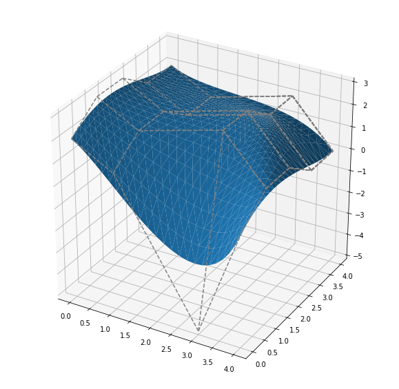

```python
fig = plt.figure(figsize=(10,10))
ax = fig.gca(projection='3d')
ax.plot_trisurf(X, Y, Z)
common.bfs(P, ax)
plt.show()
```

## Бикубические B-сплайновые поверхности

### Определение

По заданному множеству вершин $\{P_{ij}\}, 0 \le i \le 3, 0 \le j \le 3$ **бикубическая B-сплайновая поверхность** определяется следующим уравнением: $\vec{R}(u,v)=\sum\limits_{i=0}^3 \sum\limits_{j=0}^3 n_i(u)n_j(v)\vec{P_{ij}}, 0 \le u, v \le 1$ , где функциональные элементы задаются следующим способом:

$n_0(u)=\dfrac{1}{6}(1-u)^3 \\ \\ n_1(u)=\dfrac{1}{6}(3u^3-6u^2+4) \\ \\ n_2(u)=\dfrac{1}{6}(-3u^3+3u^2+3u+1) \\ \\ n_3(u)=\dfrac{u^3}{6}$.

## Составные бикубические B-сплайновые поверхности

**Составной бикубической B-сплайновой поверхностю** называется поверхность, построенная на массиве точек $\{P_{ij}\}, 0 \le i \le n, 0 \le j \le m$ следующим образом: зададим поверхность следующим уравнением $\vec{R^{(i,j)}}(u,v)=\sum\limits_{k=0}^3 \sum\limits_{l=0}^3 n_k(u)n_l(v)\vec{P}_{i-1+k, j-1+k}, 0 \le u, v \le 1, 1 \le i \le n - 2, 1 \le j \le m - 2$,

$S^{(i,j)} -$ поверхность, заданная предыдущим уравнением. То есть поверхность $S^{(i,j)}$ строится на массиве точек $P_{l,k}, i-1\le l \le i+2, j-1 \le k \le j+2$. Тогда составная поверхность будет состоять из $(n-2)(m-2)$ элементарных поверхностей $S^{(i,j)}$, то есть $S=\cup_{i=1}^{n-2}\cup_{j=1}^{m-2}S^{(i,j)}$.

### Сравнение с составной поверхностью Безье

Основные свои свойства составная поверхность наследует от элементарной B-сплайновой. Вот некоторые свойства, отличающие составные поверхности Безье и B-сплайновую

- При изменении одной точки необходимо пересчитать одну поверхность Безье и 16 B-сплайновых
- Поверхность Безье лучше "повторяет" опорный граф, так как проходит через угловые точки опорных массивов элементарных поверхностей.
- B-сплайновая поверхность в общем случае $C^2$-гладкая.

Последнее свойство является большим преимуществом составной B-сплайновой над Безье.

Таким образом, если сравнивать составные поверхности Безье и B-сплайновые, получается, что первые лучше приближают опорный массив, а вторые являются гладкими.

### Визуализация

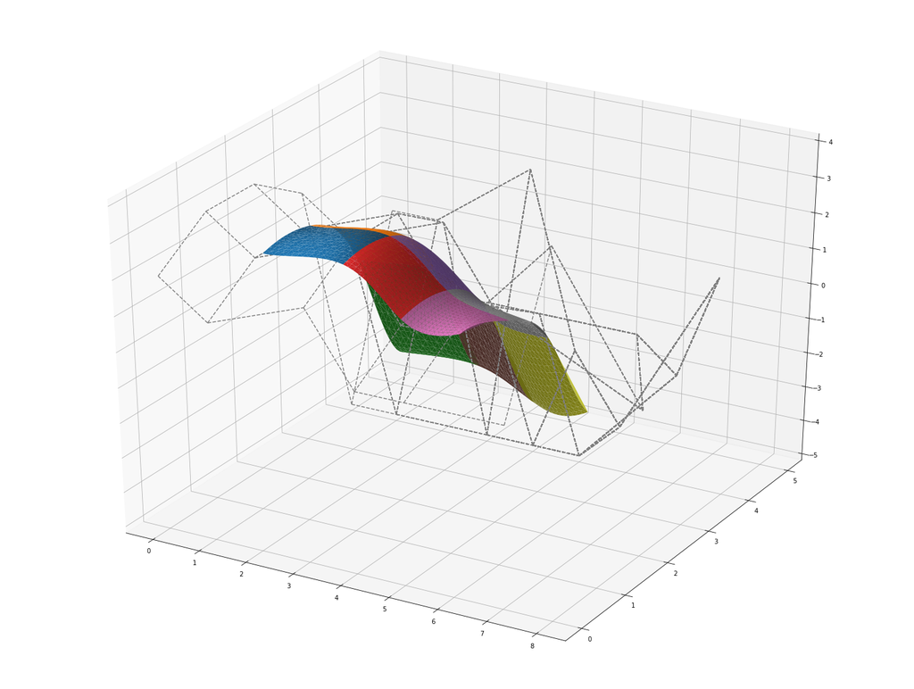

```python
fig = plt.figure(figsize=(20, 15))
ax = Axes3D(fig)
ans = b_spine_surface(P_B, ax)
common.bfs(P_B, ax)
plt.show()
```